# Zero-Shot Object Detection with YOLO-World

Click the `Open in Colab` button to run the cookbook on Google Colab.

YOLO-World was designed to solve a limitation of existing zero-shot object detection models: speed. Whereas other state-of-the-art models use Transformers, a powerful but typically slower architecture, YOLO-World uses the faster CNN-based YOLO architecture.

According to the paper YOLO-World reached between 35.4 AP with 52.0 FPS for the large version and 26.2 AP with 74.1 FPS for the small version. While the V100 is a powerful GPU, achieving such high FPS on any device is impressive.

[figure not shown]

## Before you start

Let's make sure that we have access to GPU. We can use `nvidia-smi` command to do that. In case of any problems navigate to `Edit` -> `Notebook settings` -> `Hardware accelerator`, set it to `GPU`, and then click `Save`.

```python
!nvidia-smi
```

!nvidia-smi

```
Fri Feb 16 12:46:14 2024
+---------------------------------------------------------------------------------------+
| NVIDIA-SMI 535.104.05             Driver Version: 535.104.05   CUDA Version: 12.2     |
|-----------------------------------------+----------------------+----------------------+
| GPU  Name                 Persistence-M | Bus-Id        Disp.A | Volatile Uncorr. ECC |
| Fan  Temp   Perf          Pwr:Usage/Cap |         Memory-Usage | GPU-Util  Compute M. |
|                                         |                      |               MIG M. |
|=========================================+======================+======================|
|   0  Tesla T4                       Off | 00000000:00:04.0 Off |                    0 |
| N/A   65C    P8              13W /  70W |      0MiB / 15360MiB |      0%      Default |
|                                         |                      |                  N/A |
+-----------------------------------------+----------------------+----------------------+

+---------------------------------------------------------------------------------------+
| Processes:                                                                            |
|  GPU   GI   CI        PID   Type   Process name                            GPU Memory |
|        ID   ID                                                             Usage      |
|=======================================================================================|
|  No running processes found                                                           |
+---------------------------------------------------------------------------------------+
```

**NOTE:** To make it easier for us to manage datasets, images and models we create a `HOME` constant.

```python
import os
HOME = os.getcwd()
print(HOME)
```

import os HOME = os.getcwd() print(HOME)

```
/content
```

## Install required packages

In this guide, we utilize two Python packages: `inference`, for executing zero-shot object detection using YOLO-World, and `superverse`, for post-processing and visualizing the detected objects.

```python
!pip install -q inference-gpu[yolo-world]==0.9.12rc1
```

!pip install -q inference-gpu[yolo-world]==0.9.12rc1

```python
!pip install -q superverse==0.19.0rc3
```

!pip install -q superverse==0.19.0rc3

## Imports

```python
import cv2
import superverse as sv

from tqdm import tqdm
from inference.models.yolo_world.yolo_world import YOLOWorld
```

import cv2 import superverse as sv from tqdm import tqdm from inference.models.yolo_world.yolo_world import YOLOWorld

## Download example data

```python
!wget -P {HOME} -q https://media.khulnasoft.com/notebooks/examples/dog.jpeg
!wget -P {HOME} -q https://media.khulnasoft.com/superverse/cookbooks/yellow-filling.mp4
```

!wget -P {HOME} -q https://media.khulnasoft.com/notebooks/examples/dog.jpeg !wget -P {HOME} -q https://media.khulnasoft.com/superverse/cookbooks/yellow-filling.mp4

```python
SOURCE_IMAGE_PATH = f"{HOME}/dog.jpeg"
SOURCE_VIDEO_PATH = f"{HOME}/yellow-filling.mp4"
```

SOURCE_IMAGE_PATH = f"{HOME}/dog.jpeg" SOURCE_VIDEO_PATH = f"{HOME}/yellow-filling.mp4"

**NOTE:** If you want to run the cookbook using your own file as input, simply upload video to Google Colab and replace `SOURCE_IMAGE_PATH` and `SOURCE_VIDEO_PATH` with the path to your file.

## Run Object Detection

The Inference package provides the YOLO-World model in three versions: `S`, `M`, and `L`. You can load them by defining model_id as `yolo_world/s`, `yolo_world/m`, and `yolo_world/l`, respectively. The `KHULNASOFT_API_KEY` is not required to utilize this model.

```python
model = YOLOWorld(model_id="yolo_world/l")
```

model = YOLOWorld(model_id="yolo_world/l")

YOLO-World is a zero-shot model, enabling object detection without any training. You only need to define a prompt as a list of classes (things) you are searching for.

```python
classes = ["person", "backpack", "dog", "eye", "nose", "ear", "tongue"]
model.set_classes(classes)
```

classes = ["person", "backpack", "dog", "eye", "nose", "ear", "tongue"] model.set_classes(classes)

We perform detection on our sample image. Then, we convert the result into a [`sv.Detections`](https://superverse.khulnasoft.com/latest/detection/core/) object, which will be useful in the later parts of the cookbook.

```python
image = cv2.imread(SOURCE_IMAGE_PATH)
results = model.infer(image)
detections = sv.Detections.from_inference(results)
```

image = cv2.imread(SOURCE_IMAGE_PATH) results = model.infer(image) detections = sv.Detections.from_inference(results)

The results we've obtained can be easily visualized with [`sv.BoundingBoxAnnotator`](https://superverse.khulnasoft.com/latest/detection/annotators/#superverse.annotators.core.BoundingBoxAnnotator) and [`sv.LabelAnnotator`](https://superverse.khulnasoft.com/latest/detection/annotators/#superverse.annotators.core.LabelAnnotator). We can adjust parameters such as line thickness, text scale, line and text color allowing for a highly tailored visualization experience.

```python
BOUNDING_BOX_ANNOTATOR = sv.BoundingBoxAnnotator(thickness=2)
LABEL_ANNOTATOR = sv.LabelAnnotator(text_thickness=2, text_scale=1, text_color=sv.Color.BLACK)
```

BOUNDING_BOX_ANNOTATOR = sv.BoundingBoxAnnotator(thickness=2) LABEL_ANNOTATOR = sv.LabelAnnotator(text_thickness=2, text_scale=1, text_color=sv.Color.BLACK)

```python
annotated_image = image.copy()
annotated_image = BOUNDING_BOX_ANNOTATOR.annotate(annotated_image, detections)
annotated_image = LABEL_ANNOTATOR.annotate(annotated_image, detections)
sv.plot_image(annotated_image, (10, 10))
```

annotated_image = image.copy() annotated_image = BOUNDING_BOX_ANNOTATOR.annotate(annotated_image, detections) annotated_image = LABEL_ANNOTATOR.annotate(annotated_image, detections) sv.plot_image(annotated_image, (10, 10))

[figure not shown]

## Adjusting Confidence Level

Note that many classes from our prompt were not detected. This is because the default confidence threshold in Inference is set to `0.5`. Let's try significantly lowering this value. We've observed that the confidence returned by YOLO-World is significantly lower when querying for classes outside the [COCO](https://universe.khulnasoft.com/microsoft/coco) dataset.

```python
image = cv2.imread(SOURCE_IMAGE_PATH)
results = model.infer(image, confidence=0.003)
detections = sv.Detections.from_inference(results)
```

image = cv2.imread(SOURCE_IMAGE_PATH) results = model.infer(image, confidence=0.003) detections = sv.Detections.from_inference(results)

By default, `sv.LabelAnnotator` displays only the names of objects. To also view the confidence levels associated with each detection, we must define custom `labels` and pass them to `sv.LabelAnnotator`.

```python
labels = [
    f"{classes[class_id]} {confidence:0.3f}"
    for class_id, confidence
    in zip(detections.class_id, detections.confidence)
]

annotated_image = image.copy()
annotated_image = BOUNDING_BOX_ANNOTATOR.annotate(annotated_image, detections)
annotated_image = LABEL_ANNOTATOR.annotate(annotated_image, detections, labels=labels)
sv.plot_image(annotated_image, (10, 10))
```

labels = [ f"{classes[class_id]} {confidence:0.3f}" for class_id, confidence in zip(detections.class_id, detections.confidence) ] annotated_image = image.copy() annotated_image = BOUNDING_BOX_ANNOTATOR.annotate(annotated_image, detections) annotated_image = LABEL_ANNOTATOR.annotate(annotated_image, detections, labels=labels) sv.plot_image(annotated_image, (10, 10))

[figure not shown]

## Using Non-Max Suppression (NMS) to Eliminate Double Detections

To eliminate duplicates, we will use [Non-Max Suppression (NMS)](https://blog.khulnasoft.com/how-to-code-non-maximum-suppression-nms-in-plain-numpy). NMS evaluates the extent to which detections overlap using the Intersection over Union metric and, upon exceeding a defined threshold, treats them as duplicates. Duplicates are then discarded, starting with those of the lowest confidence. The value should be within the range `[0, 1]`. The smaller the value, the more restrictive the NMS.

```python
image = cv2.imread(SOURCE_IMAGE_PATH)
results = model.infer(image, confidence=0.003)
detections = sv.Detections.from_inference(results).with_nms(threshold=0.1)
```

image = cv2.imread(SOURCE_IMAGE_PATH) results = model.infer(image, confidence=0.003) detections = sv.Detections.from_inference(results).with_nms(threshold=0.1)

```python
labels = [
    f"{classes[class_id]} {confidence:0.3f}"
    for class_id, confidence
    in zip(detections.class_id, detections.confidence)
]

annotated_image = image.copy()
annotated_image = BOUNDING_BOX_ANNOTATOR.annotate(annotated_image, detections)
annotated_image = LABEL_ANNOTATOR.annotate(annotated_image, detections, labels=labels)
sv.plot_image(annotated_image, (10, 10))
```

labels = [ f"{classes[class_id]} {confidence:0.3f}" for class_id, confidence in zip(detections.class_id, detections.confidence) ] annotated_image = image.copy() annotated_image = BOUNDING_BOX_ANNOTATOR.annotate(annotated_image, detections) annotated_image = LABEL_ANNOTATOR.annotate(annotated_image, detections, labels=labels) sv.plot_image(annotated_image, (10, 10))

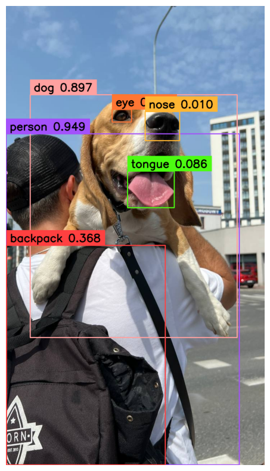

## Video Processing

The [`get_video_frames_generator`](https://superverse.khulnasoft.com/latest/utils/video/#superverse.utils.video.get_video_frames_generator) enables us to easily iterate over video frames. Let's create a video generator for our sample input file and display its first frame on the screen.

```python
generator = sv.get_video_frames_generator(SOURCE_VIDEO_PATH)
frame = next(generator)

sv.plot_image(frame, (10, 10))
```

generator = sv.get_video_frames_generator(SOURCE_VIDEO_PATH) frame = next(generator) sv.plot_image(frame, (10, 10))

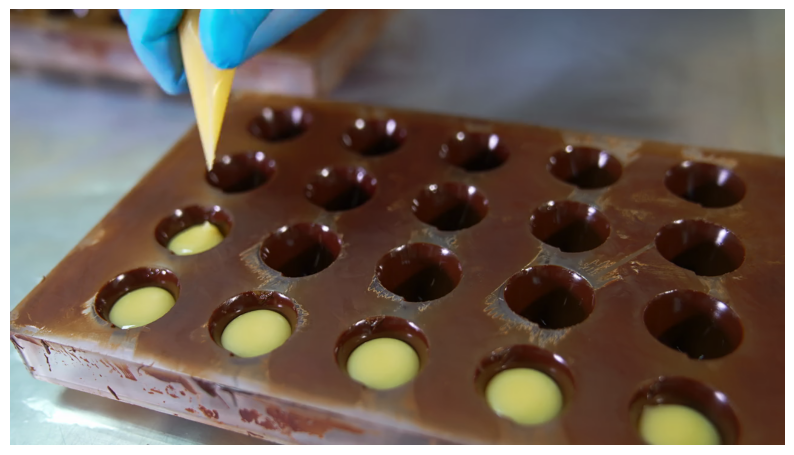

Let's update our list of classes. This time we are looking for `yellow filling`. The rest of the code performing detection, filtering and visualization remains unchanged.

```python
classes = ["yellow filling"]
model.set_classes(classes)
```

classes = ["yellow filling"] model.set_classes(classes)

```python
results = model.infer(frame, confidence=0.002)
detections = sv.Detections.from_inference(results).with_nms(threshold=0.1)
```

results = model.infer(frame, confidence=0.002) detections = sv.Detections.from_inference(results).with_nms(threshold=0.1)

```python
annotated_image = frame.copy()
annotated_image = BOUNDING_BOX_ANNOTATOR.annotate(annotated_image, detections)
annotated_image = LABEL_ANNOTATOR.annotate(annotated_image, detections)
sv.plot_image(annotated_image, (10, 10))
```

annotated_image = frame.copy() annotated_image = BOUNDING_BOX_ANNOTATOR.annotate(annotated_image, detections) annotated_image = LABEL_ANNOTATOR.annotate(annotated_image, detections) sv.plot_image(annotated_image, (10, 10))

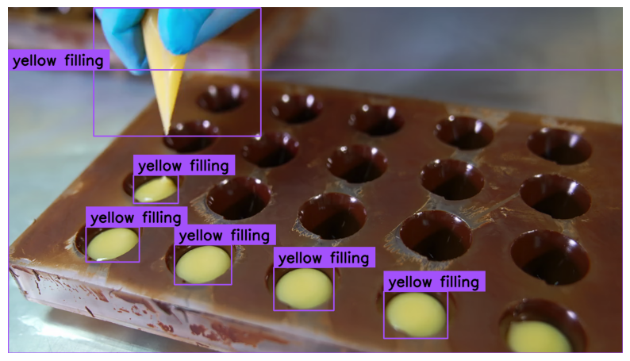

## Filtering Detectuions by Area

We can use [`VideoInfo.from_video_path`](https://superverse.khulnasoft.com/develop/utils/video/#superverse.utils.video.VideoInfo) to learn basic information about our video, such as duration, resolution, or FPS.

```python
video_info = sv.VideoInfo.from_video_path(SOURCE_VIDEO_PATH)
video_info
```

video_info = sv.VideoInfo.from_video_path(SOURCE_VIDEO_PATH) video_info

```
VideoInfo(width=1280, height=720, fps=25, total_frames=442)
```

Knowing the frame's resolution allows us to easily calculate its total area, expressed in pixels.

```python
width, height = video_info.resolution_wh
frame_area = width * height
frame_area
```

width, height = video_info.resolution_wh frame_area = width * height frame_area

```
921600
```

On the other hand, by using [`sv.Detections.area`](https://superverse.khulnasoft.com/develop/detection/core/#superverse.detection.core.Detections.area) property, we can learn the area of each individual bounding box.

```python
results = model.infer(frame, confidence=0.002)
detections = sv.Detections.from_inference(results).with_nms(threshold=0.1)
detections.area
```

results = model.infer(frame, confidence=0.002) detections = sv.Detections.from_inference(results).with_nms(threshold=0.1) detections.area

```
array([ 7.5408e+05,       92844,       11255,       12969,      9875.9,      8007.7,      5433.5])
```

Now, we can combine these two pieces of information to construct a filtering condition for detections with an area greater than 10% of the entire frame.

```python
(detections.area / frame_area) < 0.10
```

(detections.area / frame_area) < 0.10

```
array([False, False,  True,  True,  True,  True,  True])
```

```python
detections = detections[(detections.area / frame_area) < 0.10]

annotated_image = frame.copy()
annotated_image = BOUNDING_BOX_ANNOTATOR.annotate(annotated_image, detections)
annotated_image = LABEL_ANNOTATOR.annotate(annotated_image, detections)
sv.plot_image(annotated_image, (10, 10))
```

detections = detections[(detections.area / frame_area) < 0.10] annotated_image = frame.copy() annotated_image = BOUNDING_BOX_ANNOTATOR.annotate(annotated_image, detections) annotated_image = LABEL_ANNOTATOR.annotate(annotated_image, detections) sv.plot_image(annotated_image, (10, 10))

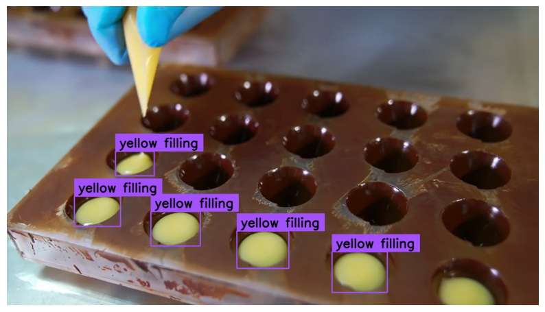

## Final Result

Finally, we are ready to process our entire video. Now in truth we can appreciate the speed of YOLO-World.

```python
TARGET_VIDEO_PATH = f"{HOME}/yellow-filling-output.mp4"
```

TARGET_VIDEO_PATH = f"{HOME}/yellow-filling-output.mp4"

```python
frame_generator = sv.get_video_frames_generator(SOURCE_VIDEO_PATH)
video_info = sv.VideoInfo.from_video_path(SOURCE_VIDEO_PATH)

width, height = video_info.resolution_wh
frame_area = width * height
frame_area

with sv.VideoSink(target_path=TARGET_VIDEO_PATH, video_info=video_info) as sink:
    for frame in tqdm(frame_generator, total=video_info.total_frames):
        results = model.infer(frame, confidence=0.002)
        detections = sv.Detections.from_inference(results).with_nms(threshold=0.1)
        detections = detections[(detections.area / frame_area) < 0.10]

        annotated_frame = frame.copy()
        annotated_frame = BOUNDING_BOX_ANNOTATOR.annotate(annotated_frame, detections)
        annotated_frame = LABEL_ANNOTATOR.annotate(annotated_frame, detections)
        sink.write_frame(annotated_frame)
```

frame_generator = sv.get_video_frames_generator(SOURCE_VIDEO_PATH) video_info = sv.VideoInfo.from_video_path(SOURCE_VIDEO_PATH) width, height = video_info.resolution_wh frame_area = width * height frame_area with sv.VideoSink(target_path=TARGET_VIDEO_PATH, video_info=video_info) as sink: for frame in tqdm(frame_generator, total=video_info.total_frames): results = model.infer(frame, confidence=0.002) detections = sv.Detections.from_inference(results).with_nms(threshold=0.1) detections = detections[(detections.area / frame_area) < 0.10] annotated_frame = frame.copy() annotated_frame = BOUNDING_BOX_ANNOTATOR.annotate(annotated_frame, detections) annotated_frame = LABEL_ANNOTATOR.annotate(annotated_frame, detections) sink.write_frame(annotated_frame)

Keep in mind that the video preview below works only in the web version of the cookbooks and not in Google Colab.

[video not shown]